# A multilevel model for groups of contingency tables

Martin Johnsson

2017-08-12

We will illustrate the structure of the model with some examples and plots.

## Binomial model for a contingency table

We can model the number of successes in each group with a binomial distribution with parameters the number of observations *n* and the probability of success *p*. The number of obsevations in each group is already known.

We need some priors for the probabilities. The beta distribution is a common choice – it gives us numbers on the 0 to 1 interval, and it can take many different shapes. Look for example at Beta(1, 1), a uniform distribution, and the very skewed Beta(1, 0.1) and Beta(0.1, 1)

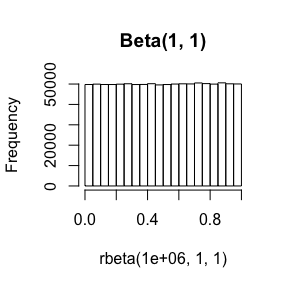

```r
hist(rbeta(1e6, 1, 1), main = "Beta(1, 1)")
```

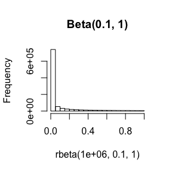

```r
hist(rbeta(1e6, 0.1, 1), xlim = c(0, 1), main = "Beta(0.1, 1)")
```

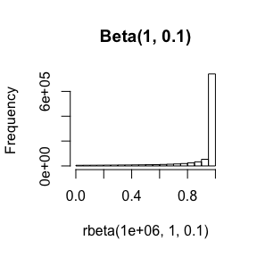

```r
hist(rbeta(1e6, 1, 0.1), xlim = c(0, 1), main = "Beta(1, 0.1)")
```

When we only have one table, we cannot make much use of this flexiblity, but it will be more useful when we move to a multilevel model. We assume the uniform Beta(1, 1) prior, we can write down this model in stan:

```
data {
    // successes
    int yA;
    int yB;
    // number of tries
    int nA;
    int nB;
}
parameters {
    real <lower = 0, upper = 1> pA;
    real <lower = 0, upper = 1> pB;
}
model {
    yA ~ binomial(nA, pA);
    yB ~ binomial(nB, pB);

    pA ~ beta(1, 1);
    pB ~ beta(1, 1);
}
generated quantities {
    // estimate difference
    real delta;
    delta = pB - pA;
}
```

This model is included in the package and called “single_binomial”. We can fit it with rstan and look at the resulting posteriors and credible intervals.

```r
model <- rstan::sampling(stanmodels$single_binomial,
                         data = list(yA = 340, nA = 10000, yB = 11, nB = 100))
```

```r
model
```

```
## Inference for Stan model: single_binomial.
## 4 chains, each with iter=2000; warmup=1000; thin=1;
## post-warmup draws per chain=1000, total post-warmup draws=4000.
##
##           mean se_mean   sd     2.5%      25%      50%      75%    97.5%
## pA        0.03    0.00 0.00     0.03     0.03     0.03     0.04     0.04
## pB        0.12    0.00 0.03     0.06     0.09     0.12     0.14     0.19
## delta     0.08    0.00 0.03     0.03     0.06     0.08     0.10     0.15
## lp__  -1525.20    0.02 1.00 -1527.84 -1525.59 -1524.90 -1524.48 -1524.21
##       n_eff Rhat
## pA     3568    1
## pB     3575    1
## delta  3564    1
## lp__   1847    1
##
## Samples were drawn using NUTS(diag_e) at Sat Aug 12 13:16:22 2017.
## For each parameter, n_eff is a crude measure of effective sample size,
## and Rhat is the potential scale reduction factor on split chains (at
## convergence, Rhat=1).
```

```
## ci_level: 0.8 (80% intervals)
```

```
## outer_level: 0.95 (95% intervals)
```

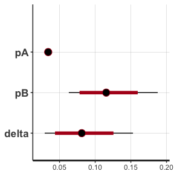

```r
rstan::plot(model)
```

A nifty thing about this approach is that we can get a posterior for the difference, `delta`, directly from the samples.

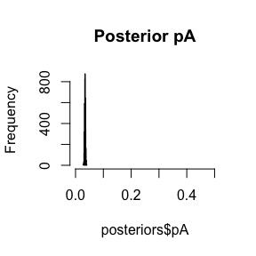

```r
posteriors <- rstan::extract(model)
hist(posteriors$pA, xlim = c(0, 0.5), main = "Posterior pA")
```

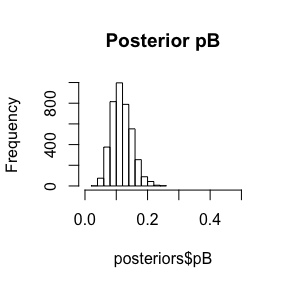

```r
hist(posteriors$pB, xlim = c(0, 0.5), main = "Posterior pB")
```

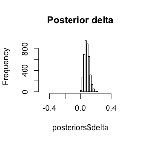

```r
hist(posteriors$delta, xlim = c(-0.5, 0.5), main = "Posterior delta")
```

## Extending the model to multiple related contingency tables

Now imagine that we’ve done the same kind of study multiple times, so that we have a list of comparable contingency tables. We would like to take advantage of this fact to borrow information between the tables when analysing them.

We can do this by allowing the parameters of the prior beta distributions to vary, and estimating their values from the data. We constrain the hyperparameters to take small values by placing half-normal priors on them.

The modifications to the model code consist of changing scalar parmeters to vectors, adding the `N` input for the number of contingency tables, and taking the average of the deltas to find the average difference between groups. At the end of the generated quantities, there is also a loop for generating simulated data from each posterior draw. This is for posterior predictive checking.

```
data {
    // number of contingency tables
    int N;
    // successes
    int yA[N];
    int yB[N];
    // number of tries
    int nA[N];
    int nB[N];
}
parameters {
    vector<lower = 0, upper = 1>[N] pA;
    vector<lower = 0, upper = 1>[N] pB;
    real<lower = 0> alphaA;
    real<lower = 0> betaA;
    real<lower = 0> alphaB;
    real<lower = 0> betaB;
}
model {
    for (i in 1:N) {
        yA[i] ~ binomial(nA[i], pA[i]);
        yB[i] ~ binomial(nB[i], pB[i]);
    }
    pA ~ beta(alphaA, betaA);
    pB ~ beta(alphaB, betaB);
    alphaA ~ normal(0, 10);
    alphaB ~ normal(0, 10);
    betaA ~ normal(0, 10);
    betaB ~ normal(0, 10);
}
generated quantities {
    vector[N] delta;
    real average_pB;
    real average_pA;
    real average_delta;

    vector[N] yA_rep;
    vector[N] yB_rep;

    // estimate average delta
    delta = pB - pA;
    average_delta = mean(delta);
    average_pB = mean(pB);
    average_pA = mean(pA);

    // posterior predictive check
    for (i in 1:N) {
        yA_rep[i] = binomial_rng(nA[i], pA[i]);
        yB_rep[i] = binomial_rng(nB[i], pB[i]);
    }
}
```